# 2019202265-贾耀博-第三周作业

# 问题一

## 1.1

### 1.1.1

**试证明：如果$X_1,X_2,\cdots,X_n$独立同分布来自$[0,1]$上的均匀分布，则对任意的$s>k$,$X_{(s)}-X_{(k)}$服从贝塔分布，第一个参数是$(s-k)$,第二个参数是$(n-s+k+1)$**

证明：

由于$X_1,X_2,\cdots,X_n \sim U[0,1]$且相互独立，从而其密度函数为$f(x)=1$，分布函数为$F(x)=x$，那么顺序统计量$X_{(s)},X_{(k)}$的联合密度函数将有如下形式，令$X_{(s)}=y$，$X_{(k)}=x$

$\begin{align}f_{k,s}(x,y) & = \frac{n!}{(k-1)!(s-k-1)!(n-s)!}F^{k-1}(x)f(x)[F(y)-F(x)]^{s-k-1}f(y)[1-F(y)]^{n-s} \\ & = \frac{n!}{(k-1)!(s-k-1)!(n-s)!}x^{k-1}(y-x)^{s-k-1}(1-y)^{n-s} \end{align}$

要想求$X_{(s)}-X_{(k)}$的分布，我们借助$X_{(k)}$先求$X_{(s)}-X_{(k)},X_{(k)}$的联合密度函数

作变换 $\begin{cases}y-x=u \\ x=v\end{cases}$

该变换的雅可比行列式为

$J=\begin{vmatrix}\frac{\partial x}{\partial u} & \frac{\partial x}{\partial v} \\ \frac{\partial y}{\partial u} & \frac{\partial y}{\partial v} \end{vmatrix}=\begin{vmatrix}0 & 1\\ 1 & 1\end{vmatrix}=-1$

那可以得到$X_{(s)}-X_{(k)},X_{(k)}$的联合密度函数

$g(u,v)=f(v,u+v)|J|=\frac{n!}{(k-1)!(s-k-1)!(n-s)!}v^{k-1}u^{s-k-1}(1-u-v)^{n-s}$

我们的目标是去求$u$的边际密度，求出边际密度则问题得解，为此我们可以对$v$在$0\to 1-u$上做积分

$h(u)=\int_0^{1-u}g(u,v)dv$

选择包含$v$的项，也就是含有$v$的核做积分，也就是求$\int_0^{1-u}v^{k-1}(1-u-v)^{n-s}dv$

作换元法积分，令$t=\frac{v}{1-u}$，则有

$\begin{align}\int_0^{1-u}v^{k-1}(1-u-v)^{n-s}dv & = \int_0^1 t^{k-1}(1-u)^{k-1}(1-u-t(1-u))^{n-s}(1-u)dt\\ & =(1-u)^{n-s+k}\int_0^1t^{k-1}(1-t)^{n-s}dt \\&= (1-u)^{n-s+k}B(k,n-s+1)\end{align}$

从而 $u \sim Beta(s-k, n-s+k+1)$

从而 $X_{(s)}-X_{(k)}$服从贝塔分布，第一个参数是$(s-k)$,第二个参数是$(n-s+k+1)$

### 1.1.2

**试证明：例1.5中，在原假设下， $\lim\limits_{n\to +\infty}E(\frac{1}{S})=\frac{1}{\sigma}$**

在原假设下，$\mu=0$，从而$p(x,\mu,\sigma)=\frac{1}{\sqrt{2\pi}}e^{-\frac{x^2}{2\sigma^2}}$，首先考虑$S^2 = \frac{1}{n-1}\sum\limits_{i=0}^{n}(X_i-\bar X)^2$

我们知道它是总体方差的无偏估计，那么$E(S^2)=\sigma^2$，也可以说$\lim\limits_{n\to +\infty}E(S^2)=\sigma^2$

另一方面，考察这个估计的方差的极限

$$\lim\limits_{n\to +\infty} Var(S^2) = \lim\limits_{n\to +\infty} Var(\frac{1}{n-1}\sum\limits_{i=0}^{n}(X_i-\bar X)^2)= \lim\limits_{n\to +\infty} \frac{2n\sigma^4}{(n-1)^2} = 0$$

这表明$S^2$是$\sigma^2$的相合估计，根据相合估计的性质，那么$S$是$\sigma$的相合估计，即$\lim\limits_{n\to +\infty}E(S)=\sigma$

进而$\frac{1}{S}$是$\frac{1}{\sigma}$的相合估计，从而得到$\lim\limits_{n\to +\infty}E(\frac{1}{S})=\frac{1}{\sigma}$

### 1.1.3

**思考布里斯托博士在不知道奶茶加奶顺序的前提下，将8杯奶茶全部猜对的可能性**

实际上我们排列8杯奶茶的顺序并不影响博士猜对奶茶的可能性，从而我们不妨假设博士依次去猜8杯奶茶，并且前四杯后后四杯不同，这样博士需要准确判断前四次即可

第一次猜对的概率是8杯中选4杯，即$P_1=\frac{4}{8}$

第二次猜对的概率是7杯中选3杯，即$P_2=\frac{3}{7}$

第三次猜对的概率是6杯中选2杯，即$P_3=\frac{2}{6}$

第四次猜对的概率是1杯中选5杯，即$P_4=\frac{1}{5}$

从而博士全部猜对的概率为 $P_1\times P_2 \times P_3 \times P_4=\frac{1}{70}$

### 1.1.4

**将例1.1的原假设和备择假设对调，即$H_0: \lambda \leq 1 \leftrightarrow H_1: \lambda > 1$, 请选择$T=\sum\limits_{i=1}^{n} X_i$ 作为统计量，当样本$n=100$时，对拒绝域$W_1=\{T \geq 117 \}$和$W_2=\{T \geq 113\}$分别绘制势函数曲线，在犯第一、二类错误的概率相等时，给出弃权域的参数范围，比较两个检验的弃权域有怎样的分布**

```r
# 原假设空间
null_hypo_rate <- seq(0,1, by=0.02)

#备择假设空间
alter_hypo_rate <- seq(1,2, by=0.02)

alpha1 <- c() #第一类错误
beta1<-c() #第二类错误


for (lambda in null_hypo_rate)
{
  alpha1<-append(alpha1,1-ppois(116,lambda = 100*lambda)) # 计算第一类错误概率
}

for (lambda in alter_hypo_rate)
{
  beta1<-append(beta1,ppois(116,lambda = 100*lambda)) # 计算第二类错误概率
}

alpha2 <- c() # 第一类错误
beta2<-c() # 第二类错误

for (lambda in null_hypo_rate)
{
  alpha2<-append(alpha2,1-ppois(112,lambda = 100*lambda)) # 计算第一类错误概率
}

for (lambda in alter_hypo_rate)
{
  beta2<-append(beta2,ppois(112,lambda = 100*lambda)) # 计算第二类错误概率
}

dt <-data.frame(alpha117=alpha1, beta117=beta1, alpha113=alpha2, beta113=beta2) # 构造数据框
```

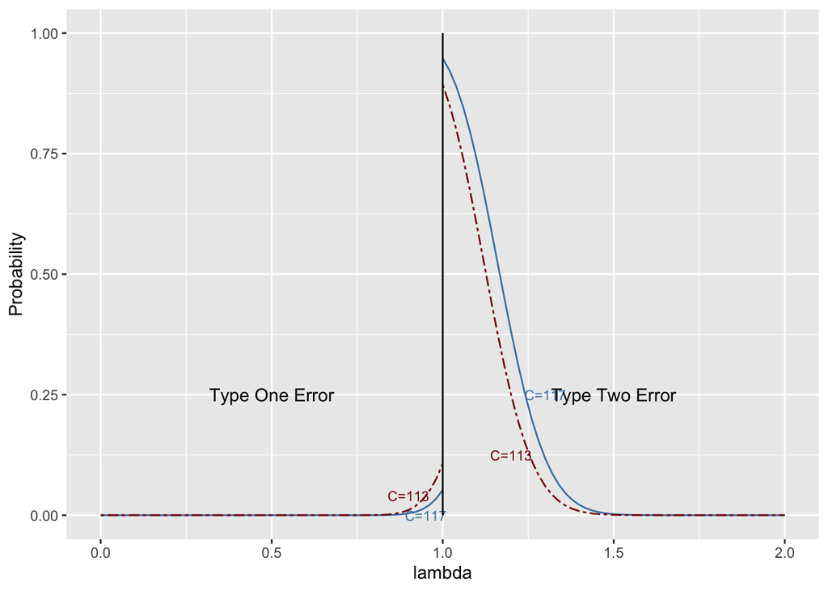

```r
library(tidyverse)
library(dplyr)

# 绘图

dt %>% ggplot() +
        geom_line(aes(x=null_hypo_rate, y=alpha117), color="steelblue")+
        annotate("text", x=0.95,y=0, label="C=117", color="steelblue",size=3)+
        geom_line(aes(x=null_hypo_rate, y=alpha113), color="darkred" ,linetype="twodash")+
        annotate("text", x=0.9,y=0.04, label="C=113", color="darkred",size=3)+
        geom_line(aes(x=alter_hypo_rate, y=beta117), color="steelblue")+
        annotate("text", x=1.3,y=0.25, label="C=117", color="steelblue",size=3)+
        geom_line(aes(x=alter_hypo_rate, y=beta113), color="darkred" ,linetype="twodash")+
        annotate("text", x=1.2,y=0.125, label="C=113", color="darkred",size=3)+
        geom_line(aes(x=rep(1,51), y=seq(0,1,length.out = 51)))+
        annotate("text", x=0.5,y=0.25,label="Type One Error")+
        annotate("text", x=1.5,y=0.25,label="Type Two Error")+
        xlab("lambda")+
        ylab("Probability")
```

从图像中观察可以发现，在$C=113$的情况下，使得犯第一类错误和第二类错误概率相等的时候，第一类错误概率确定的情况下，第二类错误概率就等于第一类错误概率，于是第二类错误概率能够被完全控制，因此在完全不能使两类错误概率相等时的备择假设空间中$\lambda$的范围即为弃权域，为$1<\lambda<1.25$

## 1.2

### 1.2.1

**根据教材1.17的数据，估计生存函数曲线，比较不同的治疗方法在减轻皮肤瘙痒方面的作用的异同，给出半衰期等指标，绘制95%生存曲线的置信带($\alpha = 0.05$)观察负对数函数对持续时间的作用，观察斜率变化，分析危险率变化比较大的位置**

```r
df<-read.csv("/Users/jiayaobo/PycharmProjects/nonparams/homework2/cowage.csv")

# 给定alpha
alpha <- 0.05
# 置信区间带
band <- sqrt((1/20)*log(2/alpha))
```

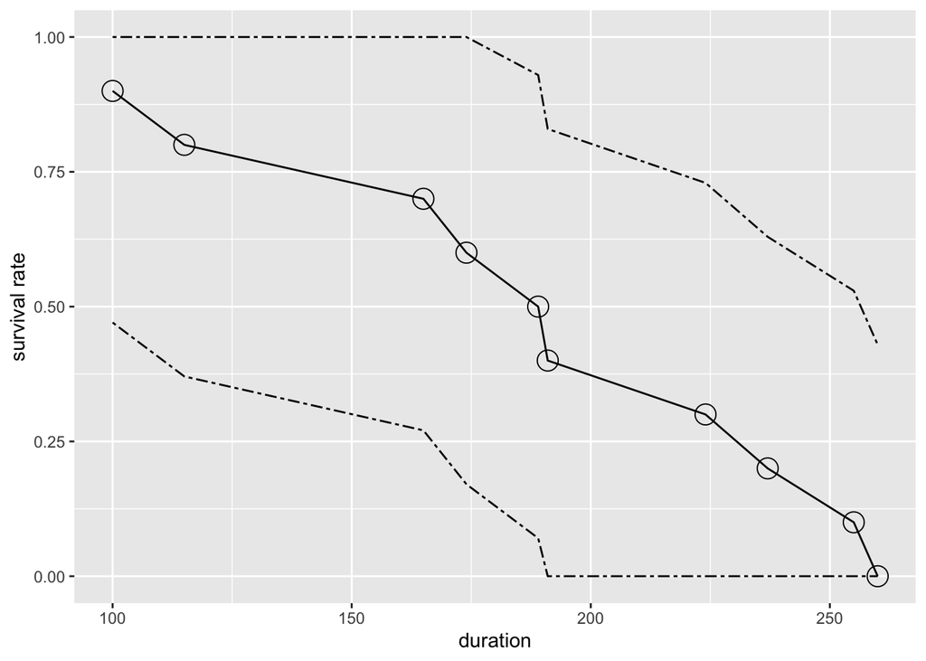

```r
# 绘制不加任何药的时候


# 经验分布
none_sort <- sort(df$none)
none_rank <- rank(none_sort)
none_cdf <-none_rank/length(none_sort)

# 经验分布上下限
none_lower <- none_cdf - band
none_upper <- none_cdf + band

for (i in seq_along(none_cdf)){
  if (none_lower[i]<0){
    none_lower[i]<-0
  }
  if(none_upper[i]>1){
    none_upper[i]<-1
  }
}


df_none <- data.frame(sort=none_sort, rank=none_rank, cdf=none_cdf, lower95=none_lower, upper95=none_upper)

df_none %>% ggplot(aes(x=sort, y=1-cdf))+
        geom_point(shape=1,size=5)+
        geom_line()+
        geom_line(aes(y=1-lower95), linetype="twodash")+
        geom_line(aes(y=1-upper95), linetype="twodash")+
        xlab("duration")+
        ylab("survival rate")
```

从图中可以得到不加任何药时的半衰期，当存活率为50%时，持续时间为189min，故半衰期为189min

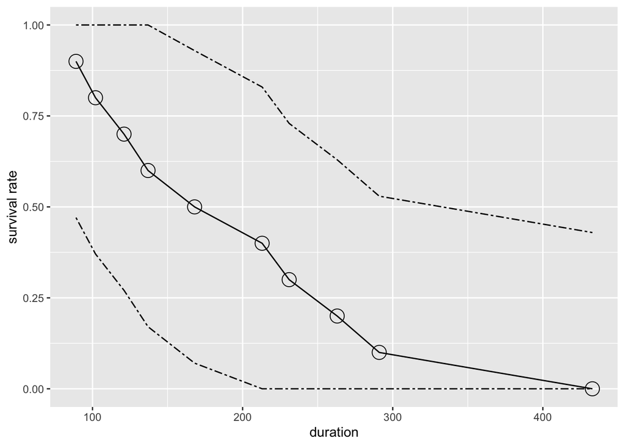

```r
# 绘制加入安慰剂的时候

#经验分布
placebo_sort <- sort(df$placebo)
placebo_rank <- rank(placebo_sort)
placebo_cdf <-placebo_rank/length(placebo_sort)

#经验分布上下限
placebo_lower <- placebo_cdf - band
placebo_upper <- placebo_cdf + band

for (i in seq_along(none_cdf)){
  if (placebo_lower[i]<0){
    placebo_lower[i]<-0
  }
  if(placebo_upper[i]>1){
    placebo_upper[i]<-1
  }
}

df_placebo <- data.frame(sort=placebo_sort, rank=placebo_rank, cdf=placebo_cdf, lower95=placebo_lower, upper95=placebo_upper)

df_placebo %>% ggplot(aes(x=sort, y=1-cdf))+
        geom_point(shape=1,size=5)+
        geom_line()+
        geom_line(aes(y=1-lower95), linetype="twodash")+
        geom_line(aes(y=1-upper95), linetype="twodash")+
        xlab("duration")+
        ylab("survival rate")
```

从图中可以得到使用安慰剂时的半衰期，当存活率为50%时，持续时间为168min，故半衰期为168min

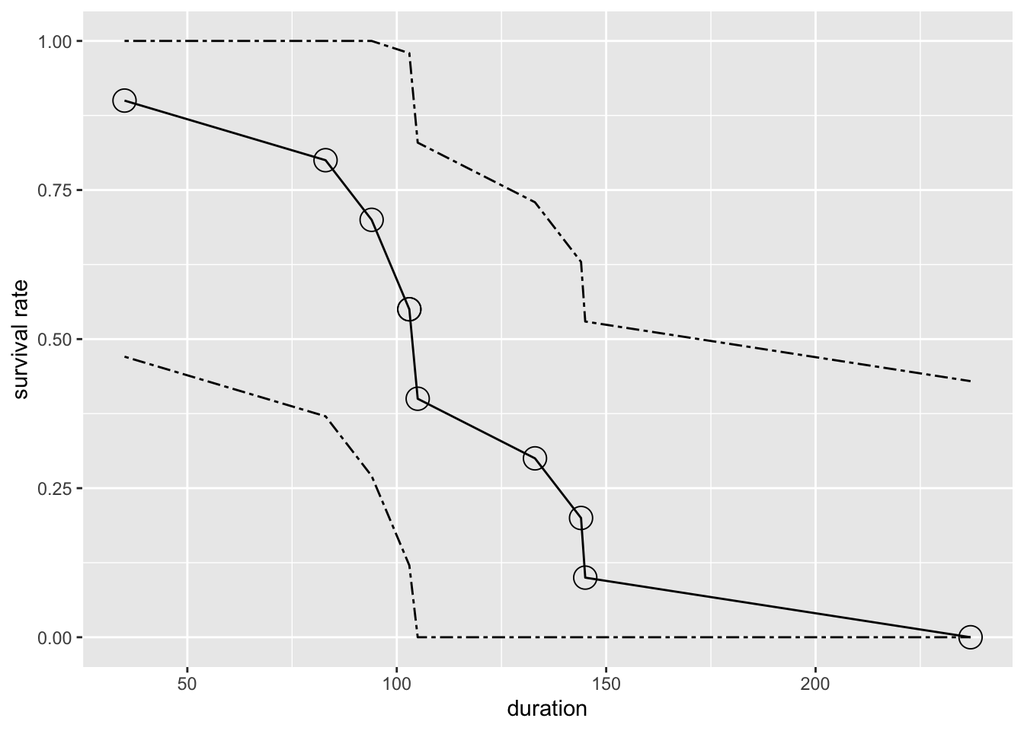

```r
papaverine_sort <- sort(df$papaverine)
papaverine_rank <- rank(papaverine_sort)
papaverine_cdf <-papaverine_rank/length(papaverine_sort)
papaverine_lower <- papaverine_cdf - band
papaverine_upper <- papaverine_cdf + band

for (i in seq_along(none_cdf)){
  if (papaverine_lower[i]<0){
    papaverine_lower[i]<-0
  }
  if(papaverine_upper[i]>1){
   papaverine_upper[i]<-1
  }
}

df_papaverine <- data.frame(sort=papaverine_sort, rank=papaverine_rank, cdf=papaverine_cdf, lower95=papaverine_lower, upper95=papaverine_upper)

df_papaverine %>% ggplot(aes(x=sort, y=1-cdf))+
        geom_point(shape=1,size=5)+
        geom_line()+
        geom_line(aes(y=1-lower95), linetype="twodash")+
        geom_line(aes(y=1-upper95), linetype="twodash")+
        xlab("duration")+
        ylab("survival rate")
```

从图中可以得到使用papaverine时的半衰期，当存活率为50%时，持续时间为104min，故半衰期为104min

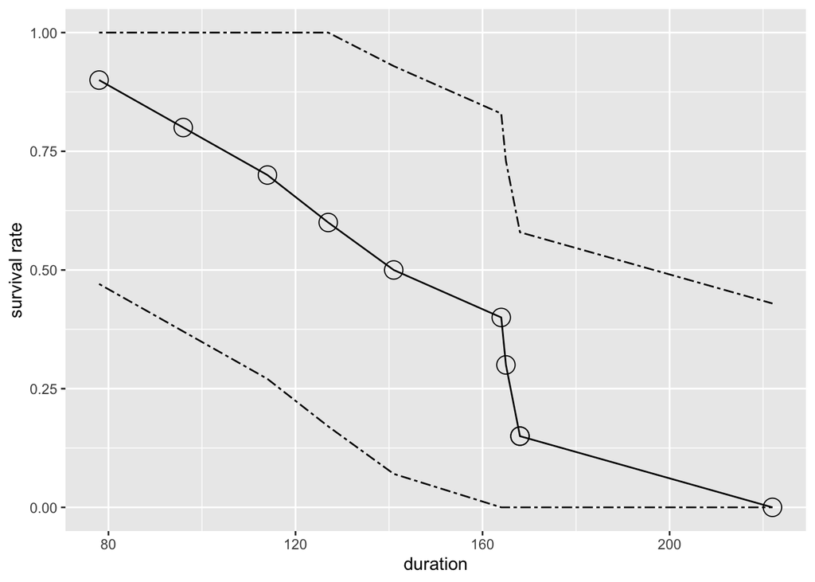

```r
aminophylline_sort <- sort(df$aminophylline)
aminophylline_rank <- rank(aminophylline_sort)
aminophylline_cdf <-aminophylline_rank/length(aminophylline_sort)
aminophylline_lower <- aminophylline_cdf - band
aminophylline_upper <- aminophylline_cdf + band

for (i in seq_along(none_cdf)){
  if (aminophylline_lower[i]<0){
    aminophylline_lower[i]<-0
  }
  if(aminophylline_upper[i]>1){
   aminophylline_upper[i]<-1
  }
}

df_aminophylline <- data.frame(sort=aminophylline_sort, rank=aminophylline_rank, cdf=aminophylline_cdf, lower95=aminophylline_lower, upper95=aminophylline_upper)

df_aminophylline %>% ggplot(aes(x=sort, y=1-cdf))+
        geom_point(shape=1,size=5)+
        geom_line()+
        geom_line(aes(y=1-lower95), linetype="twodash")+
        geom_line(aes(y=1-upper95), linetype="twodash")+
        xlab("duration")+
        ylab("survival rate")
```

从图中可以得到使用aminophylline时的半衰期，当存活率为50%时，持续时间为141min，故半衰期为141min

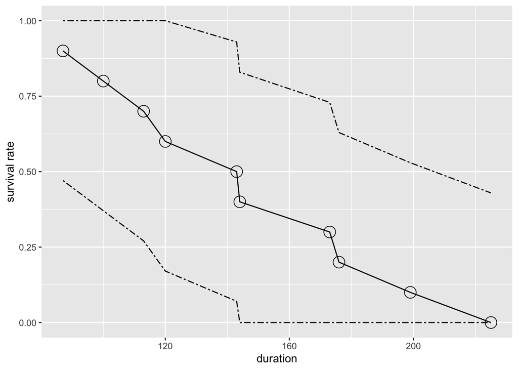

```r
morphine_sort <- sort(df$morphine)
morphine_rank <- rank(morphine_sort)
morphine_cdf <-morphine_rank/length(morphine_sort)
morphine_lower <- morphine_cdf - band
morphine_upper <- morphine_cdf + band

for (i in seq_along(none_cdf)){
  if (morphine_lower[i]<0){
    morphine_lower[i]<-0
  }
  if(morphine_upper[i]>1){
   morphine_upper[i]<-1
  }
}

df_morphine <- data.frame(sort=morphine_sort, rank=morphine_rank, cdf=morphine_cdf, lower95=morphine_lower, upper95=morphine_upper)

df_morphine %>% ggplot(aes(x=sort, y=1-cdf))+
        geom_point(shape=1,size=5)+
        geom_line()+
        geom_line(aes(y=1-lower95), linetype="twodash")+
        geom_line(aes(y=1-upper95), linetype="twodash")+
        xlab("duration")+
        ylab("survival rate")
```

从图中可以得到使用morphine时的半衰期，当存活率为50%时，持续时间为143min，故半衰期为143min

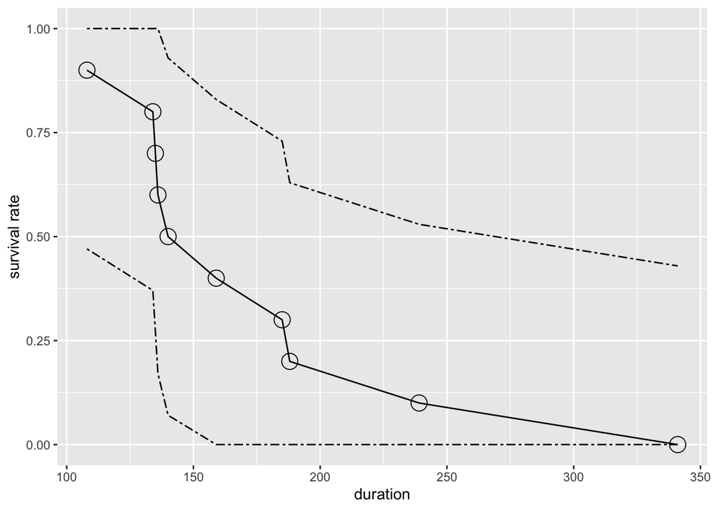

```r
pentobarbital_sort <- sort(df$pentobarbital)
pentobarbital_rank <- rank(pentobarbital_sort)
pentobarbital_cdf <-pentobarbital_rank/length(pentobarbital_sort)

pentobarbital_lower <- pentobarbital_cdf - band
pentobarbital_upper <- pentobarbital_cdf + band

for (i in seq_along(none_cdf)){
  if (pentobarbital_lower[i]<0){
   pentobarbital_lower[i]<-0
  }
  if(pentobarbital_upper[i]>1){
   pentobarbital_upper[i]<-1
  }
}

df_pentobarbital <- data.frame(sort=pentobarbital_sort, rank=pentobarbital_rank, cdf=pentobarbital_cdf, lower95=pentobarbital_lower, upper95=pentobarbital_upper)

df_pentobarbital %>% ggplot(aes(x=sort, y=1-cdf))+
        geom_point(shape=1,size=5)+
        geom_line()+
        geom_line(aes(y=1-lower95), linetype="twodash")+
        geom_line(aes(y=1-upper95), linetype="twodash")+
        xlab("duration")+
        ylab("survival rate")
```

从图中可以得到使用pentobarbital时的半衰期，当存活率为50%时，持续时间为140min，故半衰期为140min

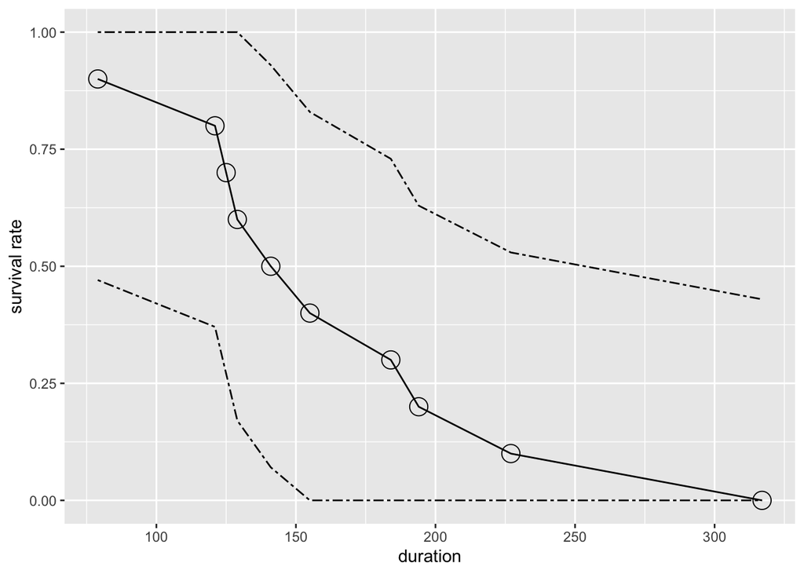

```r
tripelennamine_sort <- sort(df$tripelennamine)
tripelennamine_rank <- rank(tripelennamine_sort)
tripelennamine_cdf <-tripelennamine_rank/length(tripelennamine_sort)
tripelennamine_lower <- tripelennamine_cdf - band
tripelennamine_upper <- tripelennamine_cdf + band

for (i in seq_along(none_cdf)){
  if (tripelennamine_lower[i]<0){
   tripelennamine_lower[i]<-0
  }
  if(tripelennamine_upper[i]>1){
   tripelennamine_upper[i]<-1
  }
}

df_tripelennamine <- data.frame(sort=tripelennamine_sort, rank=tripelennamine_rank, cdf=tripelennamine_cdf, lower95=tripelennamine_lower, upper95=tripelennamine_upper)

df_tripelennamine %>% ggplot(aes(x=sort, y=1-cdf))+
        geom_point(shape=1,size=5)+
        geom_line()+
        geom_line(aes(y=1-lower95), linetype="twodash")+
        geom_line(aes(y=1-upper95), linetype="twodash")+
        xlab("duration")+
        ylab("survival rate")
```

从图中可以得到使用tripelennamine时的半衰期，当存活率为50%时，持续时间为141min，故半衰期为141min

```r
df_total <- data.frame(none=df_none$cdf,placebo=df_placebo$cdf,papaverine=df_papaverine$cdf,aminophylline=df_aminophylline$cdf,morphine=df_morphine$cdf,pentobarbital=df_pentobarbital$cdf,tripelennamine=df_tripelennamine$cdf)

df_total %>% head()
```

```
##   none placebo papaverine aminophylline morphine pentobarbital tripelennamine
## 1  0.1     0.1       0.10           0.1      0.1           0.1            0.1
## 2  0.2     0.2       0.20           0.2      0.2           0.2            0.2
## 3  0.3     0.3       0.30           0.3      0.3           0.3            0.3
## 4  0.4     0.4       0.45           0.4      0.4           0.4            0.4
## 5  0.5     0.5       0.45           0.5      0.5           0.5            0.5
## 6  0.6     0.6       0.60           0.6      0.6           0.6            0.6
```

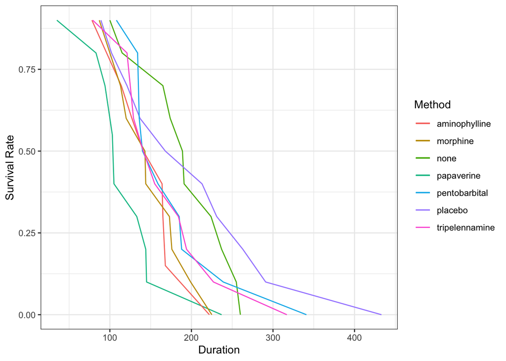

```r
# 绘制所有的生存函数

df_total %>% ggplot()+
        geom_line(aes(x=df_none$sort, y=1-none, color="none"))+
        geom_line(aes(x=df_placebo$sort, y=1-placebo, color="placebo"))+
        geom_line(aes(x=df_papaverine$sort, y=1-papaverine, color="papaverine"))+
        geom_line(aes(x=df_aminophylline$sort, y=1-aminophylline, color="aminophylline"))+
        geom_line(aes(x=df_morphine$sort, y=1-morphine, color="morphine"))+
        geom_line(aes(x=df_pentobarbital$sort, y=1-pentobarbital, color="pentobarbital"))+
        geom_line(aes(x=df_tripelennamine$sort, y=1-tripelennamine, color="tripelennamine"))+
        labs(color="Method")+
        xlab("Duration")+
        ylab("Survival Rate")+
        theme_bw()
```

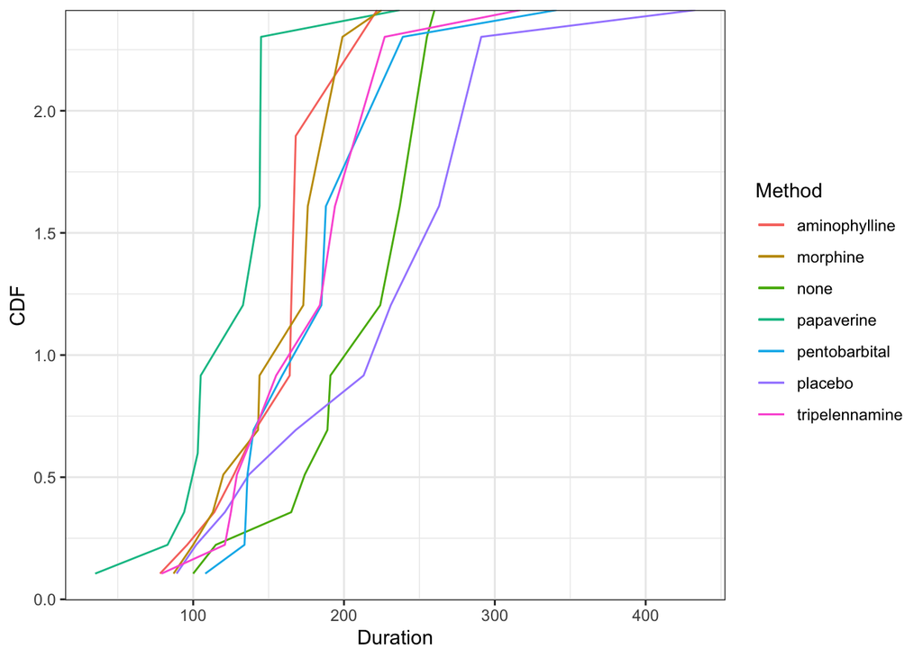

```r
# 绘制负对数函数函数

df_total %>% ggplot()+
        geom_line(aes(x=df_none$sort, y=-log(1-none), color="none"))+
        geom_line(aes(x=df_placebo$sort, y=-log(1-placebo), color="placebo"))+
        geom_line(aes(x=df_papaverine$sort, y=-log(1-papaverine), color="papaverine"))+
        geom_line(aes(x=df_aminophylline$sort, y=-log(1-aminophylline), color="aminophylline"))+
        geom_line(aes(x=df_morphine$sort, y=-log(1-morphine), color="morphine"))+
        geom_line(aes(x=df_pentobarbital$sort, y=-log(1-pentobarbital), color="pentobarbital"))+
        geom_line(aes(x=df_tripelennamine$sort, y=-log(1-tripelennamine), color="tripelennamine"))+
        labs(color="Method")+
        xlab("Duration")+
        ylab("CDF")+
        theme_bw()
```

从负对数函数图像中，我们可以从曲线的斜率看出危险函数随时间duration的变化。开始的时候危险率是比较小的，随着时间增加，而后危险率有一个明显的上升，瘙痒结束时间的变化速率增加得变快。并且papaverine以及aminophylline组的斜率要比其他组大一些，当duration很大的时候，对所有组，危险率有有一个明显的下降，并且比一开始的危险率还要低。

# 问题二

## 2.1

### (a)

**经验分布函数是那个随机变量的分布函数，这个随机变量是怎样从原始变量中转化而来的**

当有独立随机样本$X_1,X_2,\cdots,X_n$时，对 $\forall x \in R$, 定义

$$\hat{F}_n(x)=1\over n \sum\limits_{i=1}^{n}I(X_i<x)$$

式中，$I(X<x)$是示性函数：

$$I(X<x)=\begin{cases}1, X<x \\ 0, X\geq x\end{cases}$$

如果定义一个离散型随机变量$Z$,Z是在$\{x_1,x_2,\cdots,x_n\}$均匀分布的随机变量，$Z$的分布就是$\hat{F}_n(x)$

## 2.2

### (b)

**请根据数据wage.s,制作所有工资数据的经验分布函数，通过DKW不等式给出分布函数的置信区间**

```r
wage <- read.csv("/Users/jiayaobo/PycharmProjects/nonparams/homework2/wage_s.csv")

# 计算cdf
wage_sort <- sort(wage$wage)
wage_rank <- rank(wage_sort)
wage_cdf <-wage_rank/length(wage_sort)

df_wage <- data.frame(sort=wage_sort, rank=wage_rank, cdf=wage_cdf)
```

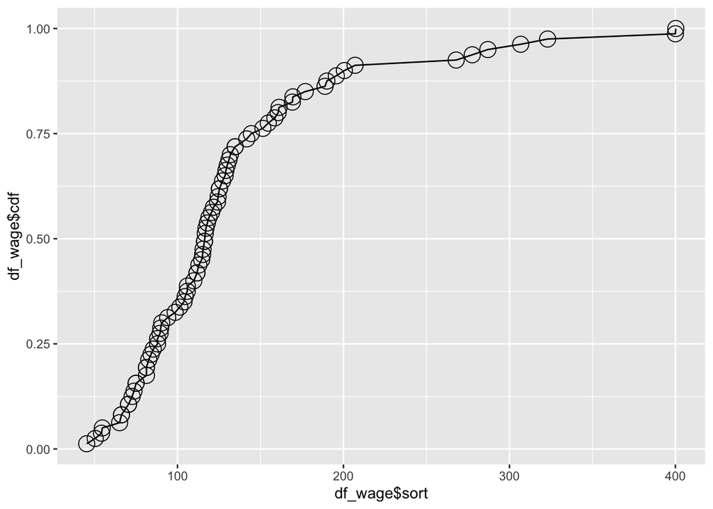

```r
# 绘制经验分布

df_wage %>% ggplot(aes(x=df_wage$sort, y=df_wage$cdf))+
        geom_point(shape=1,size=5)+
        geom_line()
```

wage的经验分布图像如上，根据DKW不等式， $\forall \varepsilon > 0$

$$P(\sup\limits_x |\hat{F}_n(x)-F(x)|>\varepsilon)\leq 2e^{-2n\varepsilon^2}$$

如果我们取犯第一类错误的概率为$\alpha$，那么我们可以构造一个置信区间。令$\varepsilon_n^2=ln(2/\alpha)(2n), L(x)=max\{\hat{F}_n(x)-\varepsilon_n\}, U(x)=min\{\hat{F}_n(x)+\varepsilon_n,1\}$,根据DKW不等式，可以得到

$$P(L(x)\leq F(x)\leq U(x))\geq 1-\alpha$$

现令$\alpha = 0.05$,绘制95%的经验函数置信区间

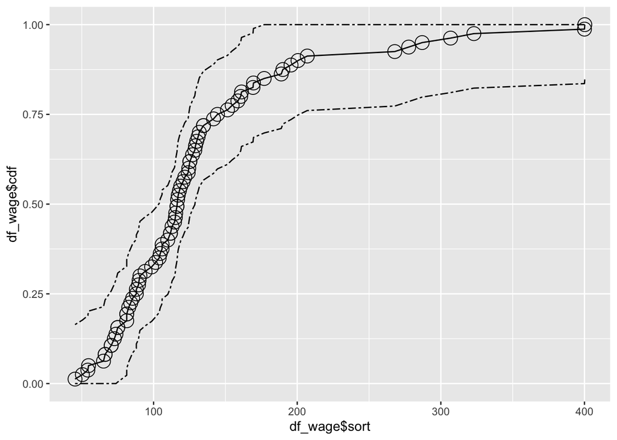

```r
# 给定alpha
alpha <- 0.05
# 置信区间带
band <- sqrt((1/160)*log(2/alpha))

wage_upper <- wage_cdf + band
wage_lower <- wage_cdf - band

for (i in seq_along(wage_cdf)){
  if (wage_lower[i]<0){
   wage_lower[i]<-0
  }
  if(wage_upper[i]>1){
   wage_upper[i]<-1
  }
}

df_wage %>% ggplot(aes(x=df_wage$sort, y=df_wage$cdf))+
        geom_point(shape=1,size=5)+
        geom_line()+
        geom_line(aes(y=wage_lower), linetype="twodash")+
        geom_line(aes(y=wage_upper), linetype="twodash")
```

## 2.3

### (c)

流程图如下

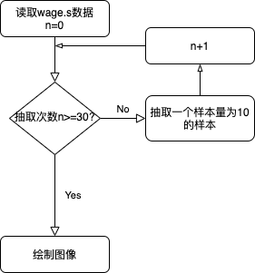

流程图

```r
# 获得样本cdf

getSampleCDFs <- function (x, size, n){ # x：data， size：sample size， n：experiment times
  df<-NULL # 初始化数据框
  for (i in 1:n){
    ss<-sample(x,size) # 抽样
    # 计算cdf
    s_sort<-sort(ss)
    s_rank<-rank(s_sort)
    s_cdf <- s_rank/size

    #得到一次抽样的数据
    temp_df <- data.frame(x=s_sort, y=s_cdf,col=rep(i:i, each=size))
    df<-rbind(df, temp_df)

  }
  return(df)
}
```

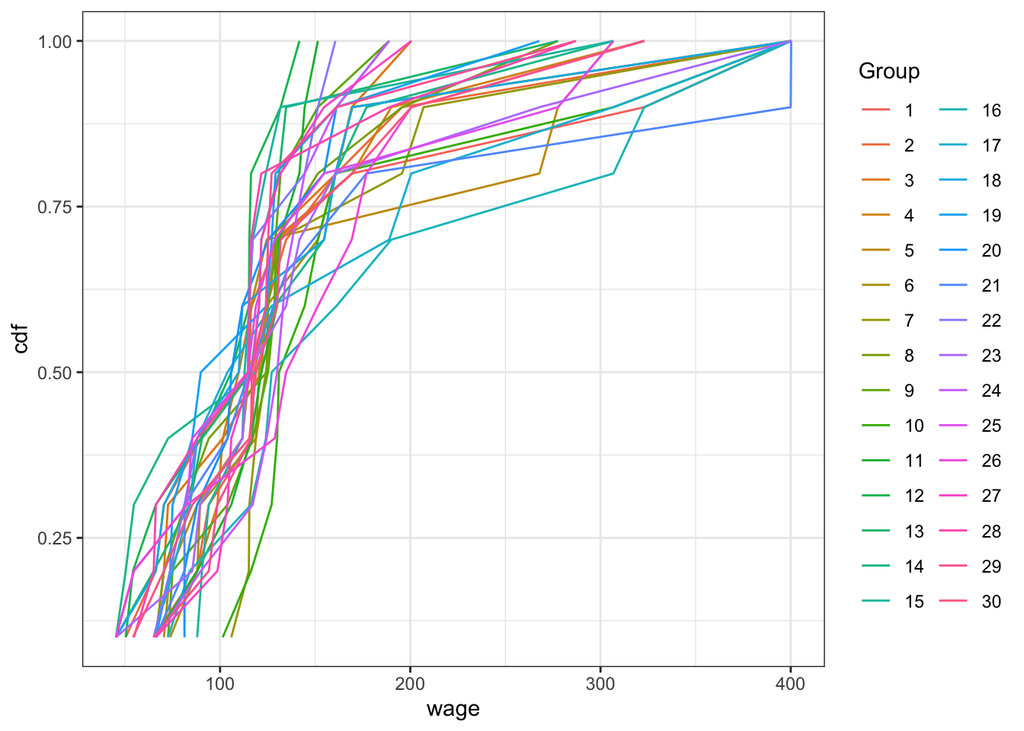

```r
sampleCDFS<-getSampleCDFs(wage$wage, 10, 30)

ggplot(sampleCDFS, aes(x=x,y=y,group=col,colour=factor(col)))+
        geom_line()+
        labs(color="Group")+
        xlab("wage")+
        ylab("cdf")+
        theme_bw()
```

```r
# 分析带宽

# 给定alpha
alpha <- 0.05
# 置信区间带，一次十个数据
band <- sqrt((1/20)*log(2/alpha))
band
```

```
## [1] 0.4294694
```

由于曲线过多，不方便在图表上会画出来，根据DKW不等式，当$\alpha=0.05$时，最终得到带宽band=0.4294694